# Evaluation of OC MS4 monitoring program, mass emissions

```r
knitr::opts_chunk$set(echo = TRUE, warning = F, message = F, fig.path = 'figs/', dev.args = list(family = 'serif'))

library(tidyverse)
library(sf)
library(mapview)
library(lubridate)
library(leafsync)
library(viridisLite)
library(lubridate)
library(gridExtra)
library(stargazer)
library(EnvStats)
library(shiny)
library(kableExtra)
library(mgcv)
library(metR)

mptyps <- c("CartoDB.Positron", "CartoDB.DarkMatter", "OpenStreetMap", "Esri.WorldImagery", "OpenTopoMap")

mapviewOptions(leafletHeight = 300)

prj <- 4326 # wgs84

source('R/funcs.R')

data(medat)
data(pows)
data(thrs)
```

## Inventory

### Maps

Watersheds monitored, number of parameters measured, and number of years monitored at each station.

```r
tomap <- medat %>%
  select(StationCode, Watershed, Longitude, Latitude) %>%
  unique %>%
  st_as_sf(coords = c('Longitude', 'Latitude'), crs = prj)

m1a <- mapview(tomap, zcol = 'Watershed', layer.name = 'Watershed location', homebutton = F, map.types = mptyps)

tomap <- medat %>%
  select(StationCode, Parameter, Longitude, Latitude) %>%
  unique %>%
  group_by(StationCode, Longitude, Latitude) %>%
  summarise(n = n()) %>%
  st_as_sf(coords = c('Longitude', 'Latitude'), crs = prj)

m2a <- mapview(tomap, zcol = 'n', layer.name = 'Number of parameters', homebutton = F, col.regions = magma, map.types = mptyps)

tomap <- medat %>%
  select(StationCode, yr = Date, Longitude, Latitude) %>%
  mutate(yr = year(yr)) %>%
  unique %>%
  group_by(StationCode, Longitude, Latitude) %>%
  summarise(n = n()) %>%
  st_as_sf(coords = c('Longitude', 'Latitude'), crs = prj)

m3a <- mapview(tomap, zcol = 'n', layer.name = 'Number of years', homebutton = F, col.regions = magma, map.types = mptyps)

leafsync::sync(m1a, m2a, m3a, ncol = 1)
```

[interactive chart not shown]

### Nutrients, tabular

```r
sums <- medat %>%
  filter(Parameter %in% c('AmmoniaN', 'NitrateNitriteNO3', 'TKN', 'OrthoPhosphateP', 'TotalPhosphorusPO4')) %>%
  mutate(
    Parameter = case_when(
      Parameter %in% 'AmmoniaN' ~ 'Ammonia',
      Parameter %in% 'NitrateNitriteNO3' ~ 'Nitrate, Nitrite',
      Parameter %in% 'TKN' ~ 'Total Kjeldahl Nitrogen',
      Parameter %in% 'OrthoPhosphateP' ~ 'Orthophosphate',
      Parameter %in% 'TotalPhosphorusPO4' ~ 'Total Phosphorus'
    )
  ) %>%
  count(Parameter, StationCode) %>%
  bind_rows(group_by(., Parameter) %>%
              summarise(n=sum(n)) %>%
              mutate(StationCode='Total')) %>%
  bind_rows(group_by(., StationCode) %>%
              summarise(n=sum(n)) %>%
              mutate(Parameter='Total')) %>%
  spread(Parameter,n,fill=0) %>%
  select(StationCode, Ammonia, `Nitrate, Nitrite`, Orthophosphate, `Total Kjeldahl Nitrogen`, `Total Phosphorus`, Total)

alltot <- sums %>%
  filter(StationCode != 'Total')
coltot <- sums %>%
  filter(StationCode == 'Total')

totab <- bind_rows(alltot, coltot)


HTML(knitr::kable(totab, format = 'html') %>%
    kable_styling(full_width = T, font_size = 14))
```

| StationCode | Ammonia | Nitrate, Nitrite | Orthophosphate | Total Kjeldahl Nitrogen | Total Phosphorus | Total |
| --- | --- | --- | --- | --- | --- | --- |
| ACWF18 | 132 | 128 | 131 | 132 | 132 | 655 |
| BARSED | 252 | 246 | 252 | 252 | 252 | 1254 |
| BCC02 | 67 | 61 | 67 | 67 | 67 | 329 |
| BCF04 | 102 | 100 | 102 | 102 | 102 | 508 |
| CARB01 | 50 | 46 | 47 | 50 | 50 | 243 |
| CCBA01 | 51 | 46 | 50 | 51 | 51 | 249 |
| CICF25 | 167 | 162 | 167 | 167 | 167 | 830 |
| CMCG02 | 397 | 390 | 396 | 397 | 397 | 1977 |
| EGWC05 | 70 | 65 | 70 | 70 | 70 | 345 |
| FCVA03 | 60 | 56 | 58 | 60 | 60 | 294 |
| LANF08 | 97 | 97 | 97 | 97 | 97 | 485 |
| MIRF07 | 145 | 141 | 145 | 145 | 145 | 721 |
| SADF01 | 307 | 300 | 313 | 307 | 307 | 1534 |
| SDMF05 | 410 | 404 | 409 | 410 | 410 | 2043 |
| SICG03 | 1 | 1 | 1 | 1 | 1 | 5 |
| WYLSED | 263 | 257 | 262 | 263 | 263 | 1308 |
| Total | 2571 | 2500 | 2567 | 2571 | 2571 | 12780 |

## Nitrogen analyses, SDMF05

### Observed

Observed time series for major nitrogen constituents.

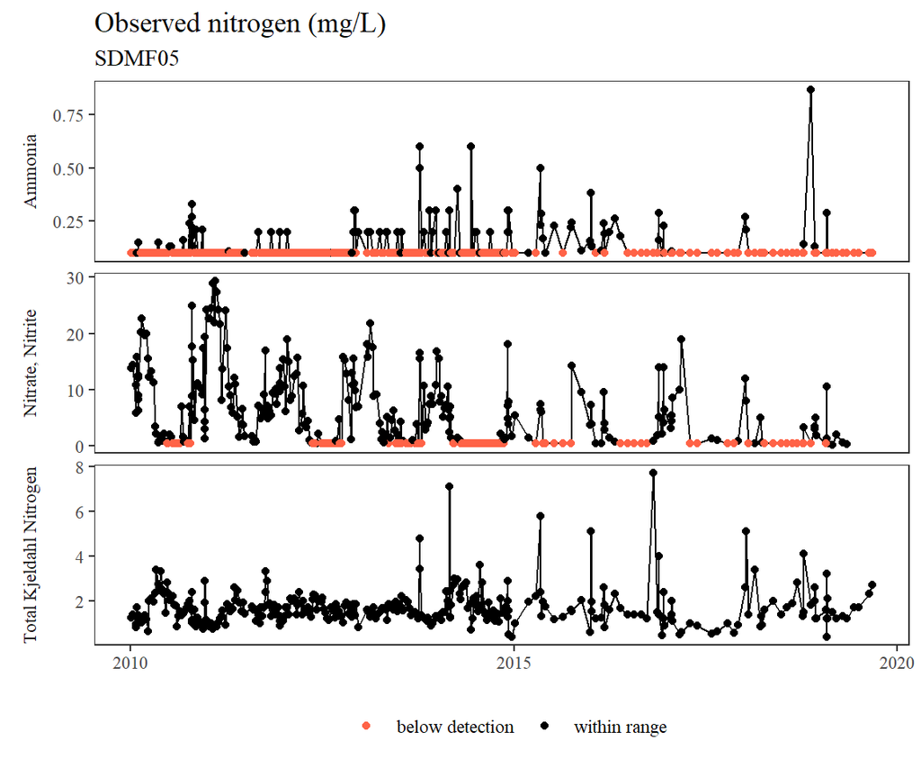

```r
thm <- theme_bw() +
  theme(
    strip.background = element_blank(),
    strip.placement = 'outside',
    axis.title = element_blank(),
    legend.title = element_blank(),
    legend.position = 'bottom',
    panel.grid = element_blank()
  )

nitdat <- medat %>%
  filter(StationCode %in% 'SDMF05') %>%
  filter(Parameter %in% c('AmmoniaN', 'NitrateNitriteNO3', 'TKN')) %>%
  mutate(
    Parameter = case_when(
      Parameter %in% 'AmmoniaN' ~ 'Ammonia',
      Parameter %in% 'NitrateNitriteNO3' ~ 'Nitrate, Nitrite',
      Parameter %in% 'TKN' ~ 'Total Kjeldahl Nitrogen'
    ),
    Detection = case_when(
      Qualifier %in% '<' ~ 'below detection',
      T ~ 'within range'
    ),
    Year = year(Date),
    Month = month(Date, label = T)
  )

toplo <- nitdat

p1 <- ggplot(toplo, aes(x = Date, y = Result)) +
  geom_line() +
  geom_point(aes(colour = Detection)) +
  facet_wrap(~Parameter, strip.position = 'left', ncol = 1, scales = 'free_y') +
  thm +
  # scale_y_log10() +
  scale_colour_manual(values = c('tomato1', 'black')) +
  labs(
    title = 'Observed nitrogen (mg/L)',
    subtitle = 'SDMF05'
  )

p2 <- ggplot(toplo, aes(x = factor(Year), y = Result, group = Year)) +
  geom_boxplot() +
  facet_wrap(~Parameter, strip.position = 'left', ncol = 1, scales = 'free_y') +
  thm +
  # scale_y_log10() +
  # scale_colour_manual(values = c('tomato1', 'black')) +
  labs(
    title = 'Observed nitrogen (mg/L) by year',
    subtitle = 'SDMF05'
  )

p3 <- ggplot(toplo, aes(x = Month, y = Result, group = Month)) +
  geom_boxplot() +
  facet_wrap(~Parameter, strip.position = 'left', ncol = 1, scales = 'free_y') +
  thm +
  # scale_y_log10() +
  # scale_colour_manual(values = c('tomato1', 'black')) +
  labs(
    title = 'Observed nitrogen (mg/L) by month',
    subtitle = 'SDMF05'
  )

p1
```

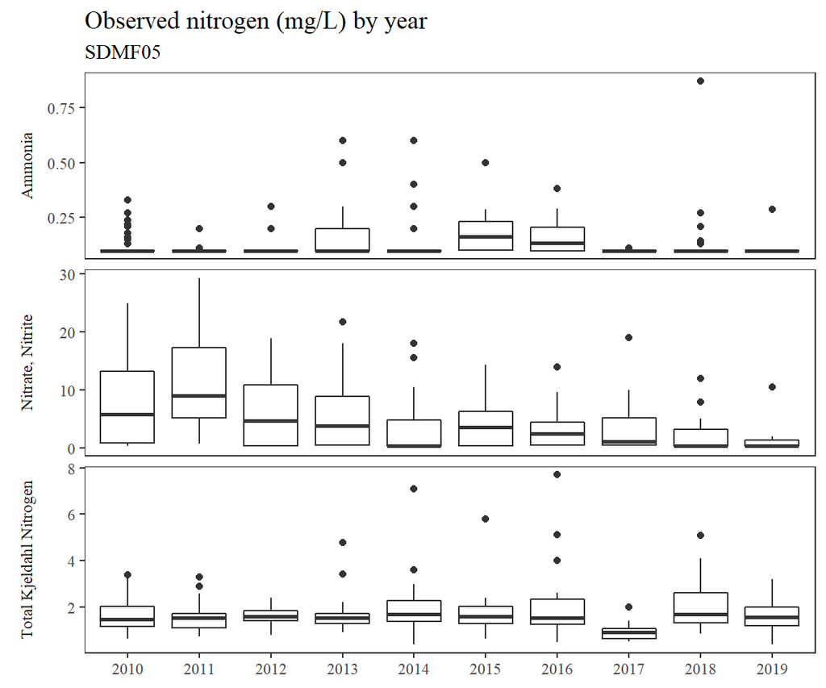

```r
p2
```

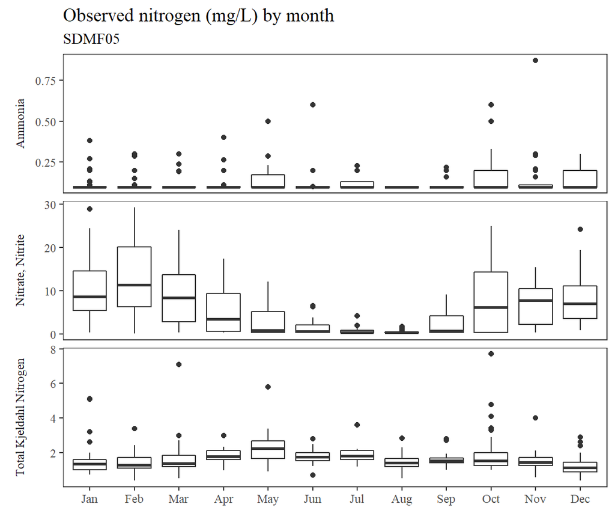

```r
p3
```

### Trends

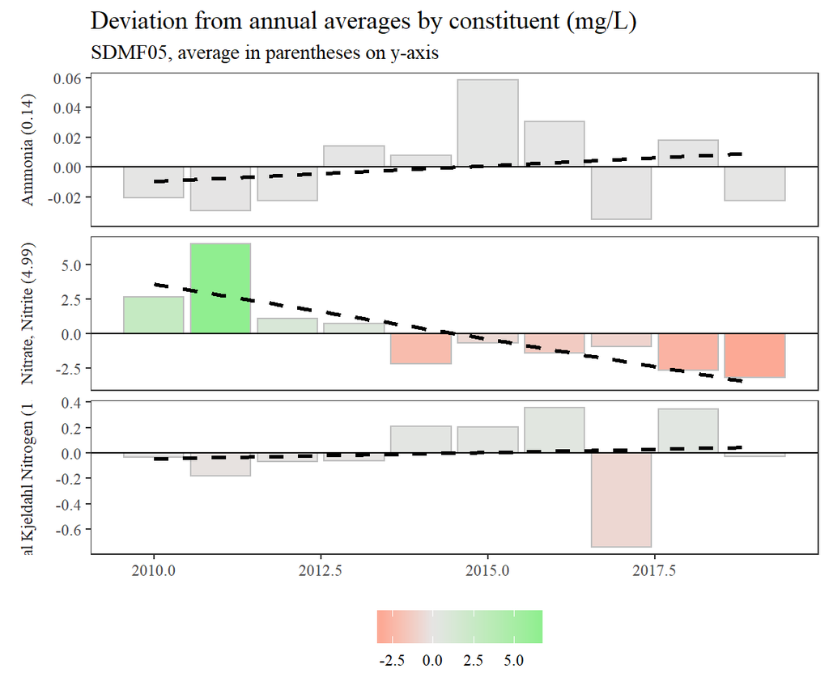

```r
thm <- theme_bw() +
  theme(
    strip.background = element_blank(),
    strip.placement = 'outside',
    axis.title = element_blank(),
    legend.title = element_blank(),
    legend.position = 'bottom',
    panel.grid = element_blank()
  )

toplo <- nitdat %>%
  group_by(Parameter, Year) %>%
  summarise(
    confint = t.test(Result)$conf.int %>% range %>% diff,
    confint = confint / 2,
    Result = mean(Result, na.rm = T),
  ) %>%
  group_by(Parameter) %>%
  mutate(
    avg = mean(Result, na.rm = T),
    dev = Result - avg
  ) %>%
  ungroup %>%
  mutate(
    avg = round(avg, 2),
    Parameter = paste0(Parameter, ' (', avg, ')')
  )

p1 <- ggplot(toplo, aes(x = Year, y = dev, fill = dev)) +
  geom_bar(stat = 'identity', colour = 'grey') +
  # geom_errorbar(aes(ymin = dev - confint, ymax = dev + confint), width = 0) +
  scale_fill_gradient2('Deviations from average (+/-)', low = 'tomato1', mid = 'grey90', high = 'lightgreen', midpoint = 0) +
  facet_wrap(~Parameter, strip.position = 'left', ncol = 1, scales = 'free_y') +
  thm +
  geom_smooth(method = 'lm', se = F, linetype = 'dashed', color = 'black') +
  # scale_y_log10() +
  # scale_y_continuous('Density (fish/100ft)') +
  geom_hline(aes(yintercept = 0)) +
  labs(
    title = 'Deviation from annual averages by constituent (mg/L)',
    subtitle = 'SDMF05, average in parentheses on y-axis'
  )

p1
```

This table shows the regression results from the above plot.

```r
mods <- toplo %>%
  group_by(Parameter) %>%
  nest %>%
  mutate(
    mod = purrr::map(data, function(x) lm(dev ~ Year, x))
  ) %>%
  ungroup %>%
  mutate(
    Parameter = gsub('\\s\\(.*\\)$', '', Parameter)
  )

stargazer(mods$mod, type = 'html',
          covariate.labels = c('Year', 'Intercept'),
          column.labels = mods$Parameter,
          omit.stat = c('adj.rsq', 'ser'),
          column.sep.width = '10pt',
          dep.var.labels.include = F,
          digits = 2
          )
```

|  | *Dependent variable:* |  |  |
| --- | --- | --- | --- |
|  | Ammonia | Nitrate, Nitrite | Total Kjeldahl Nitrogen |
|  | (1) | (2) | (3) |
| Year | 0.002 | -0.80*** | 0.01 |
|  | (0.003) | (0.19) | (0.04) |
| Intercept | -4.27 | 1,611.91*** | -20.25 |
|  | (7.04) | (383.47) | (74.81) |
| Observations | 10 | 10 | 10 |
| R<sup>2</sup> | 0.04 | 0.69 | 0.01 |
| F Statistic (df = 1; 8) | 0.37 | 17.67*** | 0.07 |
| *Note:* | p<0.1; p<0.05; p<0.01 |  |  |

The plots below show the observed time series (left) with measurements averaged to year/month (left) and a moving window average for a 12 month period with deviations around the average (right).

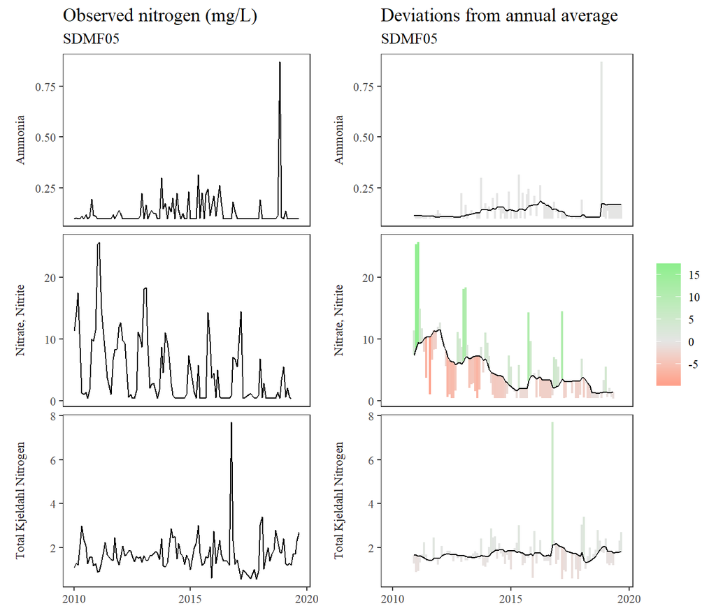

```r
win <- 12
toplo <- nitdat %>%
  select(Date, Parameter, Result) %>%
  mutate(Date = floor_date(Date, unit = 'month')) %>%
  group_by(Date, Parameter) %>%
  summarise(Result = mean(Result, na.rm = T)) %>%
  # group_by(Parameter) %>%
  arrange(Parameter, Date) %>%
  group_by(Parameter) %>%
  mutate(
    avg = stats::filter(Result, rep(1, win)/win, sides = 1, method = 'convolution')
  ) %>%
  ungroup %>%
  mutate(
    dev = Result - avg
  )

p1 <- ggplot(toplo, aes(x = Date, y = Result)) +
  geom_line() +
  facet_wrap(~Parameter, strip.position = 'left', ncol = 1, scales = 'free_y') +
  thm +
  # scale_y_log10() +
  labs(
    title = 'Observed nitrogen (mg/L)',
    subtitle = 'SDMF05'
  )

p2 <- ggplot(toplo, aes(x = Date, y = avg)) +
  geom_segment(aes(x = Date, xend = Date, yend = avg, y = avg + dev, colour = dev), size = 0.8) +
  geom_line(colour = 'black') +
  facet_wrap(~Parameter, strip.position = 'left', ncol = 1, scales = 'free_y') +
  thm +
  theme(legend.position = 'right') +
  # scale_y_log10() +
  scale_colour_gradient2('Devation from average (+/-)', low = 'tomato1', mid = 'grey90', high = 'lightgreen', midpoint = 0) +
  labs(
    title = 'Deviations from annual average',
    subtitle = 'SDMF05',
    y = NULL
  )

grid.arrange(
  arrangeGrob(p1, p2, ncol = 2, widths = c(0.8,1))
)
```

Kendall tests also provide an indication of a trend by evaluating magnitude, direction, and significance of a change in density between the selected years. The test is a non-parametric equivalent to the regression analysis above. The value for tau ranges from -1 to 1 and provides a measure of trend direction. The slope is the estimated change per year in density and the p-value shows the significance of the test.

```r
totabs1kn <- nitdat %>%
  group_by(Parameter, Year) %>%
  summarise(
    Result = mean(Result, na.rm = T),
  ) %>%
  group_by(Parameter) %>%
  mutate(
    avg = mean(Result, na.rm = T),
    dev = Result - avg
  ) %>%
  nest %>%
  mutate(
    res = purrr::map(data, function(x){

      knout <- kendallTrendTest(dev ~ Year, x)
      outest <- round(knout$estimate, 2)
      outpval <- p_ast(knout$p.value)
      nval <- nrow(na.omit(x))
      out <- c(n = nval, outest, pval = outpval) %>%
        data.frame %>%
        t %>%
        data.frame %>%
        select(-intercept)
      return(out)

    })

  ) %>%
  select(-data) %>%
  unnest(res)

HTML(knitr::kable(totabs1kn, format = 'html') %>%
    kable_styling(full_width = T, font_size = 14))
```

| Parameter | n | tau | slope | pval |
| --- | --- | --- | --- | --- |
| Ammonia | 10 | 0.16 | 0 | ns |
| Nitrate, Nitrite | 10 | -0.78 | -0.65 | ** |
| Total Kjeldahl Nitrogen | 10 | 0.29 | 0.05 | ns |